# Project 2021 TIDE

Berthony Sully & Landy Clément

9/16/2021

### 1.Proposer un code permettant de regrouper les données contenues dans movies.zip dans un seul et même data.frame.

```r
#Attach the necessary libraries
library(dplyr)
library(readr)
library(DT)

#1. Capture the raw pat of the zip folder
raw_path <- "./movies.zip"

#2. unzip the folder
data <- unzip(raw_path, files = NULL, list = F, exdir = "movie_unzip")

#3. Capture the new path to the folder that contains the datasets
path_ <- "./movie_unzip"

#4. Create a function to merge all the datasets
merge_df = function(path_to_folder){

  #capture the names of the files in the folder
  list_name_file = list.files(path = path_to_folder, full.names = T)

  #read all the files in the folder
  data_list = lapply(list_name_file, function(x){
    read.csv(file = x, header = TRUE)
    }) #x --> names of the files to read (in this case 'list_name_file')

  #combine the datasets with the reduce function
  #after merging them two by two (merge function)
  Reduce(function(x, y){merge(x, y, all = T)}, data_list)
}

#5. Store the complete merged dataset
# df <- merge_df(path_)

# write.csv(x = df, file = "complete_data.csv")

dt <- read.csv(file = "./complete_data.csv", header = T)
```

### 2. Observer pour chaque variable, le nombre et la proportion de valeurs manquantes.

#### nombre de valeurs manquantes

```r
sapply(dt,function(x) sum(is.na(x)))
```

```
##                     X         imdb_title_id                 title
##                     0                     0                     0
##        original_title                  year        date_published
##                     0                     0                     0
##                 genre              duration               country
##                     0                     0                     0
##              language              director                writer
##                     2                     1                     2
##    production_company                actors           description
##                     1                     0                     1
##              avg_vote                 votes                budget
##                     0                     0                   100
##      usa_gross_income worlwide_gross_income             metascore
##                   365                   116                 72550
##    reviews_from_users  reviews_from_critics           avg_vote_10
##                  7597                 11797                     0
##          avg_vote_100         avg_vote_1000
##                     0                     0
```

#### Nous constatons que certaines variable de la data ont des cases vides. Ainsi, nous avons décidé de les gérer comme des NAs.*

```r
dt[dt == ""]<- NA # Remplacer les vides par des NAs.
sapply(dt,function(x) sum(is.na(x)))
```

```
##                     X         imdb_title_id                 title
##                     0                     0                     0
##        original_title                  year        date_published
##                     0                     0                     0
##                 genre              duration               country
##                     0                     0                    64
##              language              director                writer
##                   833                    87                  1572
##    production_company                actors           description
##                  4455                    69                  2115
##              avg_vote                 votes                budget
##                     0                     0                 62145
##      usa_gross_income worlwide_gross_income             metascore
##                 70529                 54839                 72550
##    reviews_from_users  reviews_from_critics           avg_vote_10
##                  7597                 11797                     0
##          avg_vote_100         avg_vote_1000
##                     0                     0
```

#### Après avoir remplacé les cases vides par des Nas, nous voyons que le nbre de Nas augmente pour certaines variables et que d’autres qui n’en ont pas, ont maintenant de Nas.

#### Affichons maintenant le pourcentage de Nas pour chaque variable

```r
#  Presentage of missng values
na_percent <- round(sapply(dt,function(x) sum(is.na(x))/length(x))*100, 2)

print.table(na_percent)
```

```
##                     X         imdb_title_id                 title
##                  0.00                  0.00                  0.00
##        original_title                  year        date_published
##                  0.00                  0.00                  0.00
##                 genre              duration               country
##                  0.00                  0.00                  0.07
##              language              director                writer
##                  0.97                  0.10                  1.83
##    production_company                actors           description
##                  5.19                  0.08                  2.46
##              avg_vote                 votes                budget
##                  0.00                  0.00                 72.38
##      usa_gross_income worlwide_gross_income             metascore
##                 82.15                 63.87                 84.50
##    reviews_from_users  reviews_from_critics           avg_vote_10
##                  8.85                 13.74                  0.00
##          avg_vote_100         avg_vote_1000
##                  0.00                  0.00
```

### 3. Représenter graphiquement la distribution de la durée des films

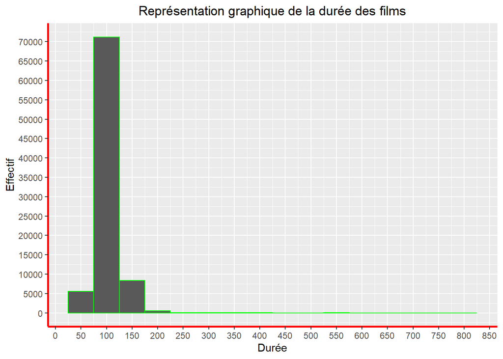

```r
library(tidyverse)
dt$duration <- as.numeric(dt$duration)
ggplot(dt, aes(x = duration, fill = duration)) +
  geom_histogram(color = "green", binwidth = 50, alpha = 1) +
  theme(plot.title = element_text(hjust = 0.5)) +
  labs(title = 'Représentation graphique de la durée des films', x = 'Durée', y = 'Effectif') +
  scale_y_continuous(n.breaks = 15) +
  scale_x_continuous(n.breaks = 15)+
  theme( axis.line = element_line(colour = "red",
                      size = 1, linetype = "solid"))
```

### 4. Compter le nombre de films dans lesquels la langue française apparait.

```r
library(stringr)
dt %>%
  filter(str_detect(language, "French|.French.")) %>%
  select(language) %>%
  count() %>%
  paste(.,'films sont disponibles en francais')
```

```
## [1] "8158 films sont disponibles en francais"
```

### 5. Créer une variable permettant de discrétiser la variable year par décennie (ex : 1975 => Entre 1970 et 1980, 1995 => Entre 1990 et 2000, 2001 => Entre 2000 et 2010…)

##### Voyons le type de la variable year

```r
paste("La variable Year est de type :", typeof(dt$year))
```

```
## [1] "La variable Year est de type : character"
```

#### On peut essayer de voir les valeurs uniques de year pour avoir une plus nette explication

```r
unique(dt$year)
```

```
##   [1] "1894"          "1906"          "1911"          "1912"
##   [5] "1919"          "1913"          "1914"          "1915"
##   [9] "1916"          "1917"          "1918"          "1920"
##  [13] "1921"          "1924"          "1922"          "1923"
##  [17] "1925"          "1926"          "1935"          "1927"
##  [21] "1928"          "1983"          "1929"          "1930"
##  [25] "1932"          "1931"          "1937"          "1938"
##  [29] "1933"          "1934"          "1936"          "1940"
##  [33] "1939"          "1942"          "1943"          "1941"
##  [37] "1948"          "1944"          "2001"          "1946"
##  [41] "1945"          "1947"          "1973"          "1949"
##  [45] "1950"          "1952"          "1951"          "1962"
##  [49] "1953"          "1954"          "1955"          "1961"
##  [53] "1956"          "1958"          "1957"          "1959"
##  [57] "1960"          "1963"          "1965"          "1971"
##  [61] "1964"          "1966"          "1968"          "1967"
##  [65] "1969"          "1976"          "1970"          "1979"
##  [69] "1972"          "1981"          "1978"          "2000"
##  [73] "1989"          "1975"          "1974"          "1986"
##  [77] "1990"          "2018"          "1977"          "1982"
##  [81] "1980"          "1993"          "1984"          "1985"
##  [85] "1988"          "1987"          "2005"          "1991"
##  [89] "2002"          "1994"          "1992"          "1995"
##  [93] "2017"          "1997"          "1996"          "2006"
##  [97] "1999"          "1998"          "2007"          "2008"
## [101] "2003"          "2004"          "2010"          "2009"
## [105] "2011"          "2013"          "2012"          "2016"
## [109] "2015"          "2014"          "2019"          "2020"
## [113] "TV Movie 2019"
```

#### La valeur “TV Movie 2019” semble être le probleme. Pour cela, étant donné qu’on connait le contexe on peut remplacer cette valeur par “2019” et convertir la variable au type ’numeric.

```r
# Select year column
dt$year <- dt$year %>%
  #convert as numeric type
  as.numeric %>%
  #replace the NA value with 2019
  replace_na(., 2019)
#show unique value of recently created year column
unique(dt$year)
```

```
##   [1] 1894 1906 1911 1912 1919 1913 1914 1915 1916 1917 1918 1920 1921 1924 1922
##  [16] 1923 1925 1926 1935 1927 1928 1983 1929 1930 1932 1931 1937 1938 1933 1934
##  [31] 1936 1940 1939 1942 1943 1941 1948 1944 2001 1946 1945 1947 1973 1949 1950
##  [46] 1952 1951 1962 1953 1954 1955 1961 1956 1958 1957 1959 1960 1963 1965 1971
##  [61] 1964 1966 1968 1967 1969 1976 1970 1979 1972 1981 1978 2000 1989 1975 1974
##  [76] 1986 1990 2018 1977 1982 1980 1993 1984 1985 1988 1987 2005 1991 2002 1994
##  [91] 1992 1995 2017 1997 1996 2006 1999 1998 2007 2008 2003 2004 2010 2009 2011
## [106] 2013 2012 2016 2015 2014 2019 2020
```

```r
#creation of the "decade variable"
dt$decade <- cut(dt$year,
                            breaks = c(seq(1890,
                                           2020, 10)),
                            labels = c("1890 - 1900",
                                       "1900 - 1910",
                                       "1910 - 1920",
                                       "1920 - 1930",
                                       "1930 - 1940",
                                       "1940 - 1950",
                                       "1950 - 1960",
                                       "1960 - 1970",
                                       "1970 - 1980",
                                       "1980 - 1990",
                                       "1990 - 2000",
                                       "2000 - 2010",
                                       "2010 - 2020"),
                            right = F,
                            include.lowest = T)

#randomly select some line in year and decade columns to verify the results
dt %>%
  select(year, decade)%>%
  sample_n(50) %>% datatable()
```

|  | year | decade |
| --- | --- | --- |
| 1 | 2012 | 2010 - 2020 |
| 2 | 2014 | 2010 - 2020 |
| 3 | 2013 | 2010 - 2020 |
| 4 | 2001 | 2000 - 2010 |
| 5 | 2018 | 2010 - 2020 |
| 6 | 1998 | 1990 - 2000 |
| 7 | 2011 | 2010 - 2020 |
| 8 | 2011 | 2010 - 2020 |
| 9 | 2014 | 2010 - 2020 |
| 10 | 2018 | 2010 - 2020 |

[output cut: 40 more lines]

### 6. Proposer une représentation graphique permettant d’observer pour chaque décennie, le nombre et la proportion de films dans lesquels la langue française apparait.

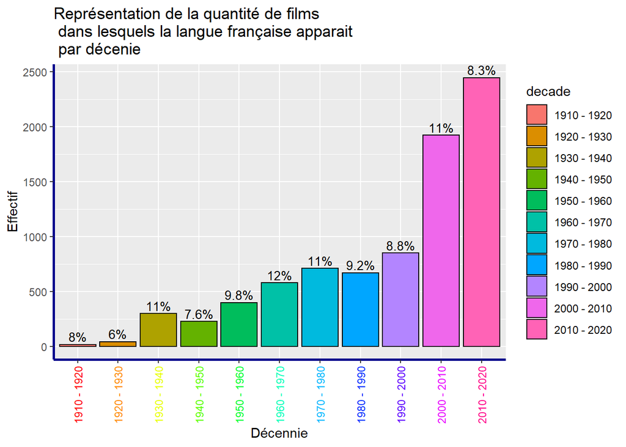

```r
df <- dt %>%
select(language, decade) %>%
group_by(decade) %>%
count(french = str_detect(language, "French|.French.")) %>%
mutate(p = scales::percent(n / sum(n))) %>%
filter(french == TRUE)

ggplot(df, aes(x=decade,y=n, fill=decade)) +
geom_bar(stat="identity", color="black")+
geom_text(aes(label=p), vjust=-0.3, size=3.5)+
theme(axis.text.x = element_text(angle=90, vjust=.5, hjust=1, colour = rainbow(11))) +
labs(title = "Représentation de la quantité de films\n dans lesquels la langue française apparait\n par décenie",
x = "Décennie", y = "Effectif")+
  theme( axis.line = element_line(colour = "darkblue",
                      size = 1, linetype = "solid"))
```

### 7. Pour toutes les variables de la forme « avg_vote ». Calculer la moyenne, la médiane, l’écart type, la mad (median absolute deviation), le coefficient de variation, la valeur maximum et la valeur minimum. Représentez graphiquement ces résultats.

#### Vu que les variables avg_vote et avg_vote_10 sont identiques, on a décidé de garder que la variable avg_vote_10.

```r
data <-dt %>%
  select(starts_with("avg_vote_"))

report <- function(x, name) {
  tibble(
    variable  = name,
    mean = round(mean(x, na.rm = FALSE), 2),
    median = round(median(x, na.rm = FALSE), 2),
    sd = round(sd(x), 2),

    mad = round(mad(x, center = median(x),
                    constant = 1.4826, na.rm = FALSE,
                    low = FALSE, high = FALSE), 2),

    coef_de_var = round((sd(x)/mean(x))*100, 2),
    max = round(max(x), 2),
    min = round(min(x), 2)
  )
}

Ind_Stat <- data %>% imap_dfr(report)


datatable(Ind_Stat,)
```

|  | variable | mean | median | sd | mad | coef_de_var | max | min |
| --- | --- | --- | --- | --- | --- | --- | --- | --- |
| 1 | avg_vote_10 | 5.9 | 6.1 | 1.23 | 1.04 | 20.94 | 9.9 | 1 |
| 2 | avg_vote_100 | 82.57 | 85.35 | 17.56 | 15.8 | 21.27 | 145.56 | 9.99 |
| 3 | avg_vote_1000 | 589.87 | 610 | 123.5 | 103.78 | 20.94 | 990 | 100 |

#### Représentez graphiquement ces résultats

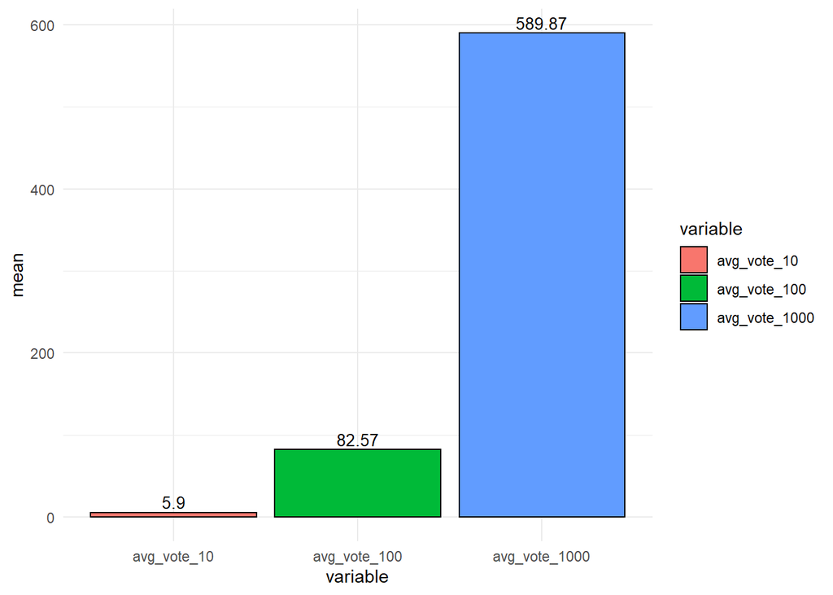

```r
ggplot(Ind_Stat, aes(x=variable, y=mean, fill=variable)) +
  geom_bar(stat="identity", color="black")+
  geom_text(aes(label=mean), vjust=-0.3, size=3.5)+
  theme_minimal()
```

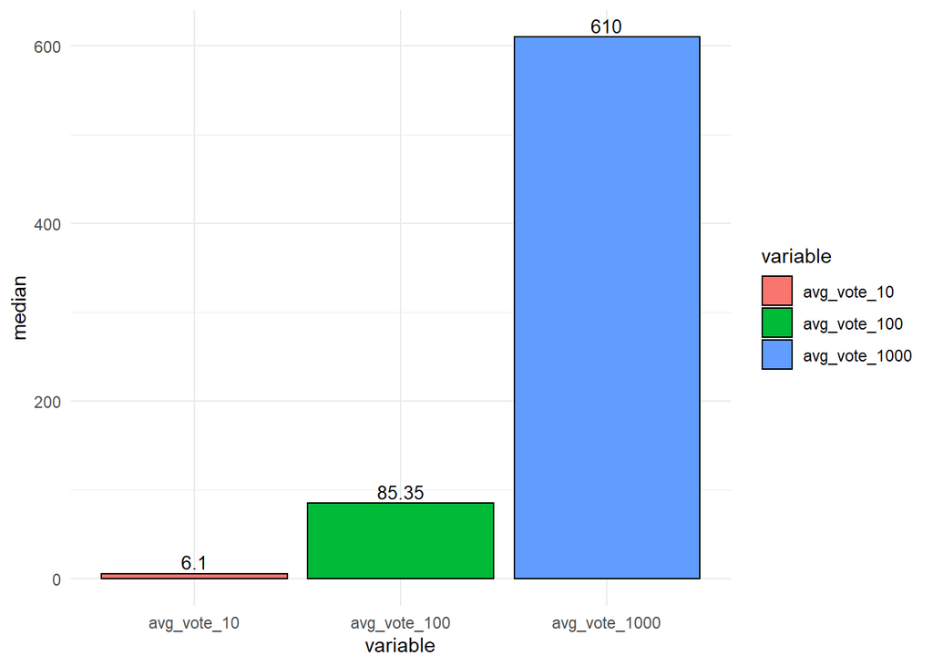

```r
ggplot(Ind_Stat, aes(x=variable, y=median, fill=variable)) +
  geom_bar(stat="identity", color="black")+
  geom_text(aes(label=median), vjust=-0.3, size=3.5)+
  theme_minimal()
```

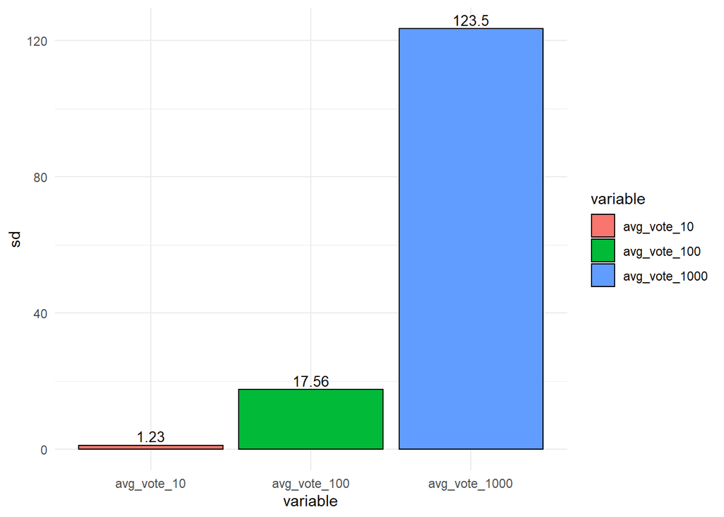

```r
ggplot(Ind_Stat, aes(x=variable, y=sd, fill=variable)) +
  geom_bar(stat="identity", color="black")+
  geom_text(aes(label=sd), vjust=-0.3, size=3.5)+
  theme_minimal()
```

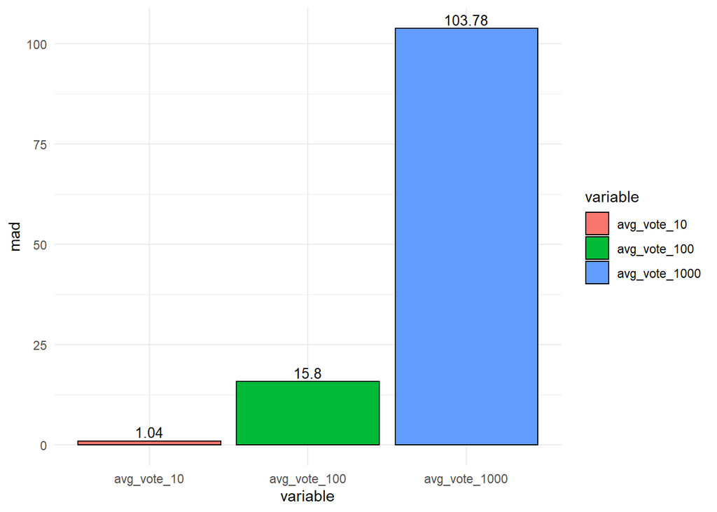

```r
ggplot(Ind_Stat, aes(x=variable, y=mad, fill=variable)) +
  geom_bar(stat="identity", color="black")+
  geom_text(aes(label=mad), vjust=-0.3, size=3.5)+
  theme_minimal()
```

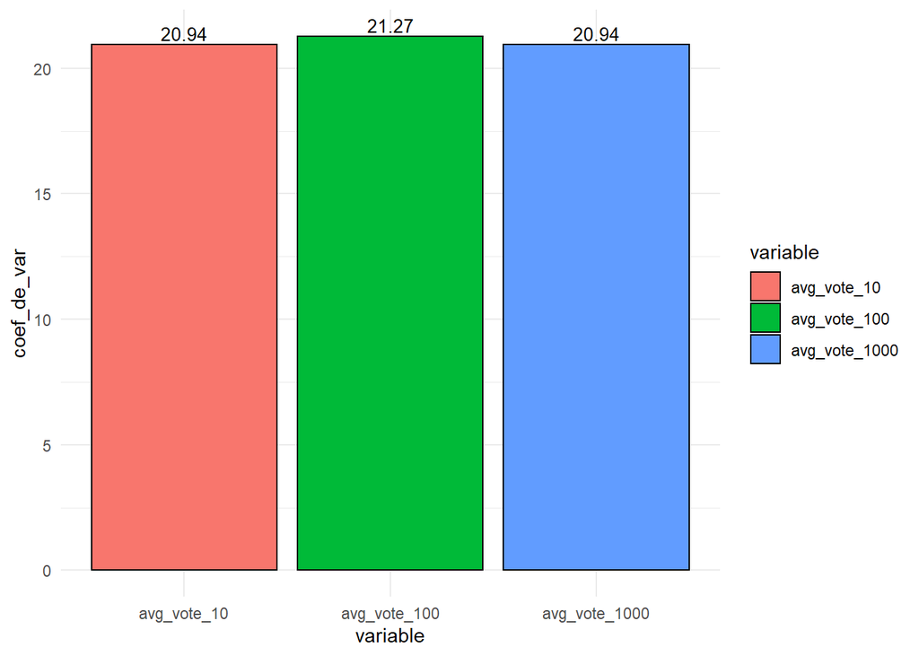

```r
ggplot(Ind_Stat, aes(x=variable, y=coef_de_var, fill=variable)) +
  geom_bar(stat="identity", color="black")+
  geom_text(aes(label=coef_de_var), vjust=-0.3, size=3.5)+
  theme_minimal()
```

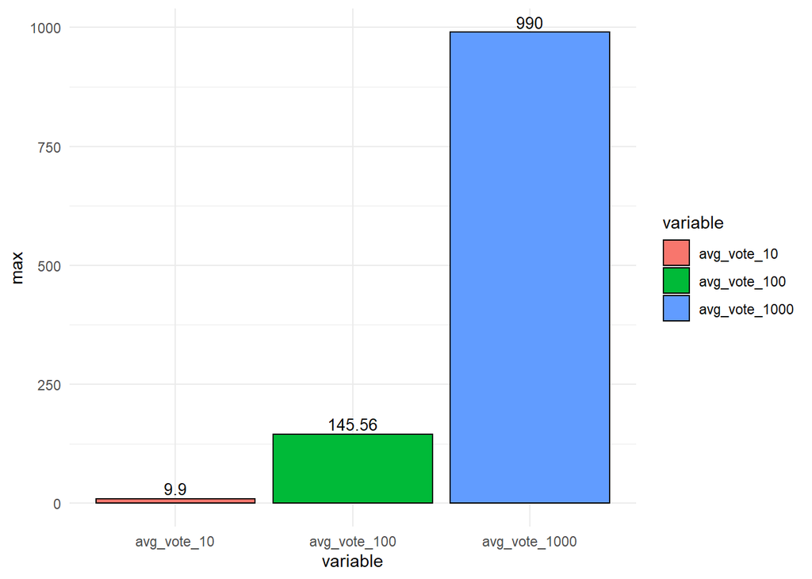

```r
ggplot(Ind_Stat, aes(x=variable, y=max, fill=variable)) +
  geom_bar(stat="identity", color="black")+
  geom_text(aes(label=max), vjust=-0.3, size=3.5)+
  theme_minimal()
```

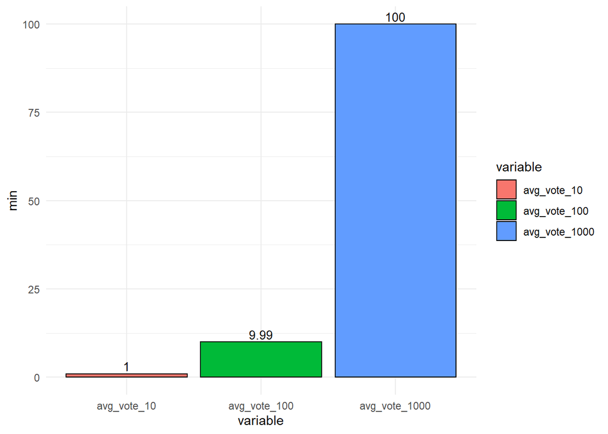

```r
ggplot(Ind_Stat, aes(x=variable, y=min, fill=variable)) +
  geom_bar(stat="identity", color="black")+
  geom_text(aes(label=min), vjust=-0.3, size=3.5)+
  theme_minimal()
```

#### 8. Proposer une représentation graphique permettant d’observer s’il existe une différence de notation en fonction du genre de film

```r
uni_ <- function(data){
  data %>%
    paste(., collapse = ",") %>%
    str_replace_all(., fixed(" "), "") %>%
    strsplit(., ",") %>%
    unlist() %>%
    unique() %>%
    sort
}
genre <- uni_(dt$genre);genre   # Visualiser le nombre de genres différents de la data
```

```
##  [1] "Action"      "Adult"       "Adventure"   "Animation"   "Biography"
##  [6] "Comedy"      "Crime"       "Documentary" "Drama"       "Family"
## [11] "Fantasy"     "Film-Noir"   "History"     "Horror"      "Music"
## [16] "Musical"     "Mystery"     "News"        "Reality-TV"  "Romance"
## [21] "Sci-Fi"      "Sport"       "Thriller"    "War"         "Western"
```

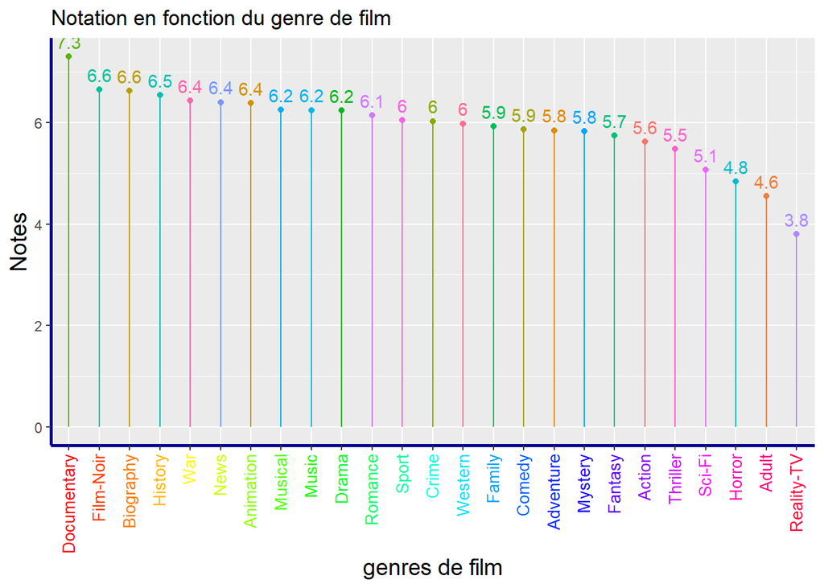

```r
avg_vote_genre <- function(x){
  dt_avg <- dt %>%
    filter(grepl(x, genre))
  return (mean(dt_avg$avg_vote))
}
note_film_genre <- genre %>%
  sapply(avg_vote_genre)
note_film_genre <- as.data.frame(note_film_genre)
names(note_film_genre)<- "avg_vote"
df_avg_vote_genre <- data.frame(genre, avg_vote=as.vector(note_film_genre))
ggplot(df_avg_vote_genre, aes(y = avg_vote, x =fct_rev(fct_reorder(genre, avg_vote,.fun="median")),color = genre)) +
  geom_point(size=1.5)+
  geom_segment(aes(x=genre, xend = genre, y=0, yend=avg_vote), fill=genre)+
  geom_text(aes(label=round(avg_vote, 1), y=avg_vote, vjust=-0.6))+
  labs(title = "Notation en fonction du genre de film", x="genres de film", y="Notes")+
  theme(legend.position = "none", axis.text.x = element_text(angle = 90, hjust = 1, vjust=.4, size = 10, colour =rainbow(25)), axis.title = element_text(size = 14))+
  theme( axis.line = element_line(colour = "darkblue",
                      size = 1, linetype = "solid"))
```

#### 9) Pour chaque genre de film, représenter graphiquement le top 10 des films les mieux notés

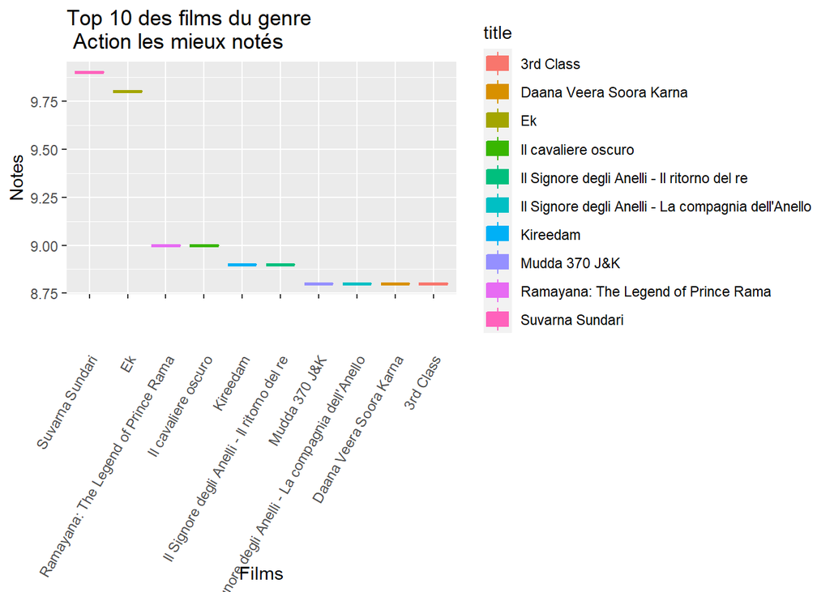

```r
Ac <- dt %>%
  filter(str_detect(genre, "Action")) %>%
  select(avg_vote, title) %>%
  arrange(desc(avg_vote)) %>%
  head(10)
ggplot(Ac, aes(y = avg_vote, x =fct_rev(fct_reorder(title, avg_vote,.fun="median")),color = title)) +
  theme(axis.text.x = element_text(vjust=.8, hjust=1, angle=60)) +
  geom_boxplot(aes(fill = title)) +
  xlab("Films") +
  ylab("Notes") +
  ggtitle("Top 10 des films du genre\n Action les mieux notés ")
```

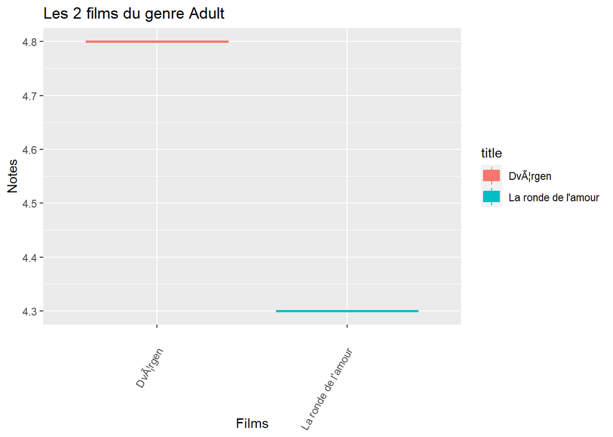

```r
 Ad <- dt %>%
  filter(str_detect(genre, "Adult")) %>%
  select(avg_vote, title) %>%
  arrange(desc(avg_vote)) %>%
  head(10)
ggplot(Ad, aes(y = avg_vote, x =fct_rev(fct_reorder(title, avg_vote,.fun="median")),color = title)) +
  theme(axis.text.x = element_text(vjust=.8, hjust=1, angle=60)) +
  geom_boxplot(aes(fill = title)) +
  xlab("Films") +
  ylab("Notes") +
  ggtitle("Les 2 films du genre Adult")
```

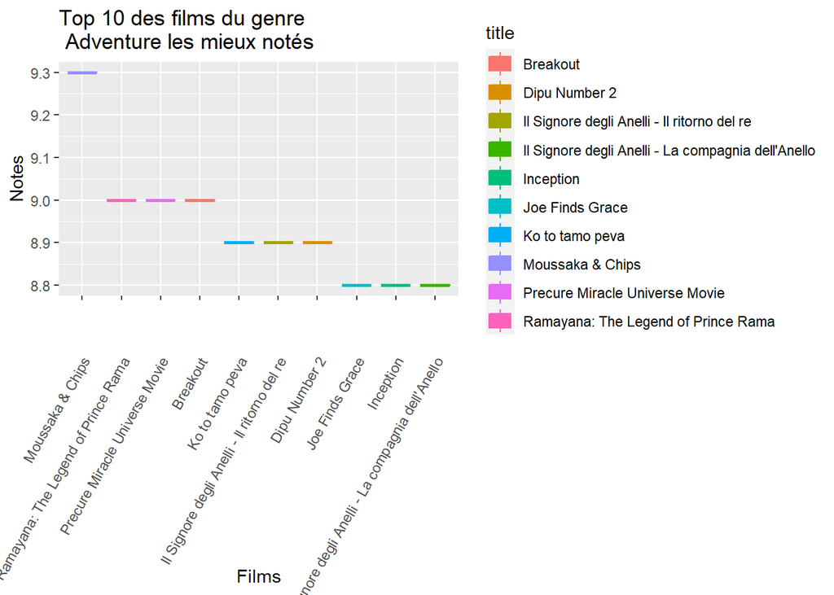

```r
Adv <- dt %>%
  filter(str_detect(genre, "Adventure")) %>%
  select(avg_vote, title) %>%
  arrange(desc(avg_vote)) %>%
  head(10)
ggplot(Adv, aes(y = avg_vote, x =fct_rev(fct_reorder(title, avg_vote,.fun="median")),color = title)) +
  theme(axis.text.x = element_text(vjust=.8, hjust=1, angle=60)) +
  geom_boxplot(aes(fill = title)) +
  xlab("Films") +
  ylab("Notes") +
  ggtitle("Top 10 des films du genre\n Adventure les mieux notés ")
```

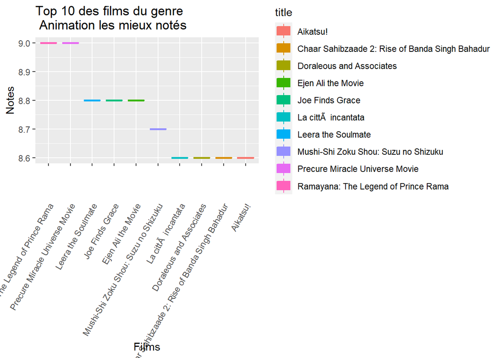

```r
Ani <- dt %>%
  filter(str_detect(genre, "Animation")) %>%
  select(avg_vote, title) %>%
  arrange(desc(avg_vote)) %>%
  head(10)
ggplot(Ani, aes(y = avg_vote, x =fct_rev(fct_reorder(title, avg_vote,.fun="median")),color = title)) +
  theme(axis.text.x = element_text(vjust=.8, hjust=1, angle=60)) +
  geom_boxplot(aes(fill = title)) +
  xlab("Films") +
  ylab("Notes") +
  ggtitle("Top 10 des films du genre\n Animation les mieux notés ")
```

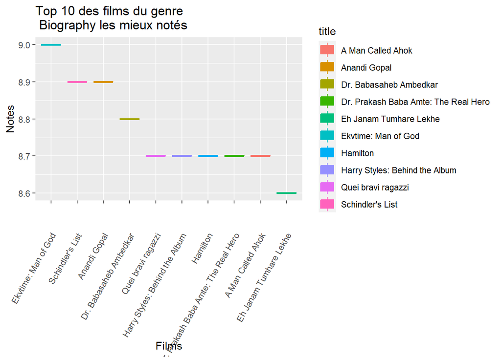

```r
Bio <- dt %>%
  filter(str_detect(genre, "Biography")) %>%
  select(avg_vote, title) %>%
  arrange(desc(avg_vote)) %>%
  head(10)
ggplot(Bio, aes(y = avg_vote, x =fct_rev(fct_reorder(title, avg_vote,.fun="median")),color = title)) +
  theme(axis.text.x = element_text(vjust=.8, hjust=1, angle=60)) +
  geom_boxplot(aes(fill = title)) +
  xlab("Films") +
  ylab("Notes") +
  ggtitle("Top 10 des films du genre\n Biography les mieux notés ")
```

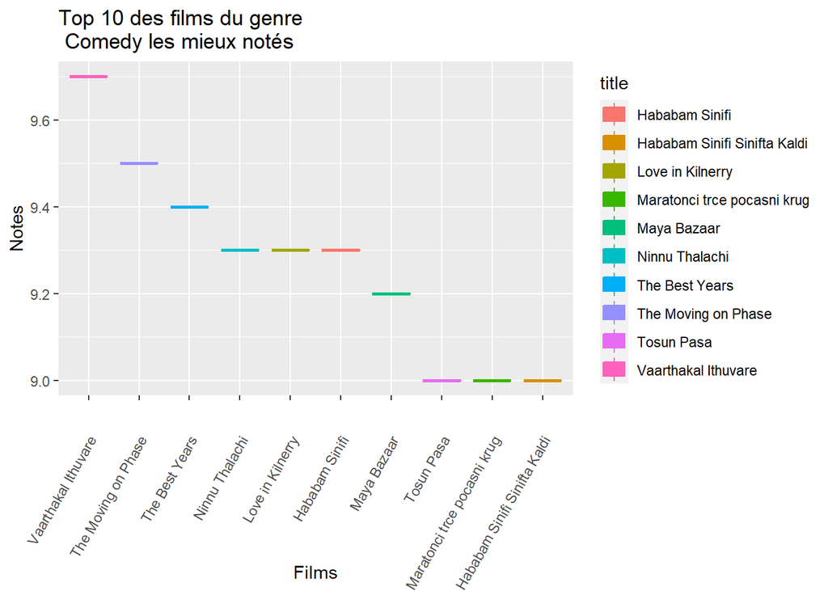

```r
Co <- dt %>%
  filter(str_detect(genre, "Comedy")) %>%
  select(avg_vote, title) %>%
  arrange(desc(avg_vote)) %>%
  head(10)
ggplot(Co, aes(y = avg_vote, x =fct_rev(fct_reorder(title, avg_vote,.fun="median")),color = title)) +
  theme(axis.text.x = element_text(vjust=.8, hjust=1, angle=60)) +
  geom_boxplot(aes(fill = title)) +
  xlab("Films") +
  ylab("Notes") +
  ggtitle("Top 10 des films du genre\n Comedy les mieux notés ")
```

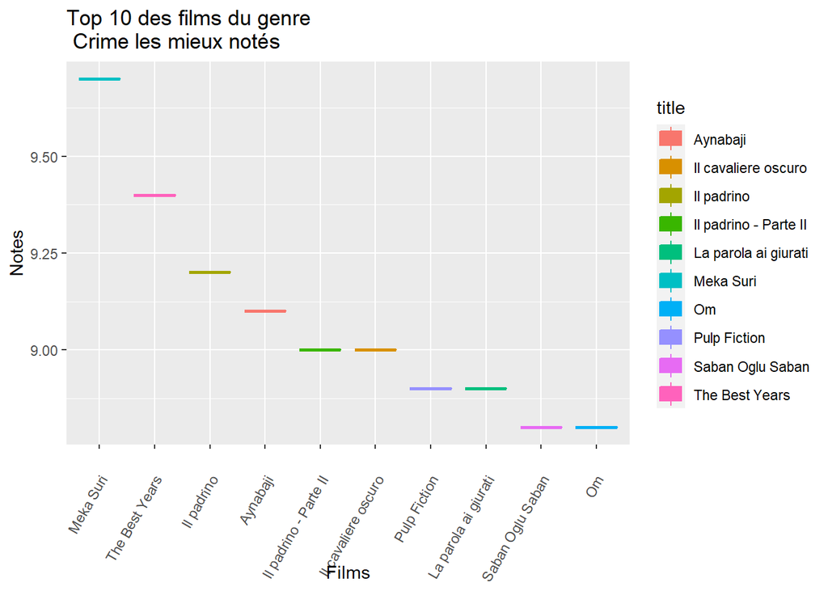

```r
Cr <- dt %>%
  filter(str_detect(genre, "Crime")) %>%
  select(avg_vote, title) %>%
  arrange(desc(avg_vote)) %>%
  head(10)
ggplot(Cr, aes(y = avg_vote, x =fct_rev(fct_reorder(title, avg_vote,.fun="median")),color = title)) +
  theme(axis.text.x = element_text(vjust=.8, hjust=1, angle=60)) +
  geom_boxplot(aes(fill = title)) +
  xlab("Films") +
  ylab("Notes") +
  ggtitle("Top 10 des films du genre\n Crime les mieux notés ")
```

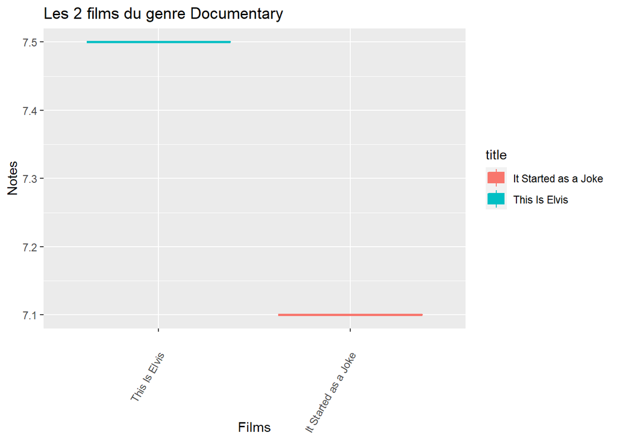

```r
Doc <- dt %>%
  filter(str_detect(genre, "Documentary")) %>%
  select(avg_vote, title) %>%
  arrange(desc(avg_vote)) %>%
  head(10)
ggplot(Doc, aes(y = avg_vote, x =fct_rev(fct_reorder(title, avg_vote,.fun="median")),color = title)) +
  theme(axis.text.x = element_text(vjust=.8, hjust=1, angle=60)) +
  geom_boxplot(aes(fill = title)) +
  xlab("Films") +
  ylab("Notes") +
  ggtitle("Les 2 films du genre Documentary")
```

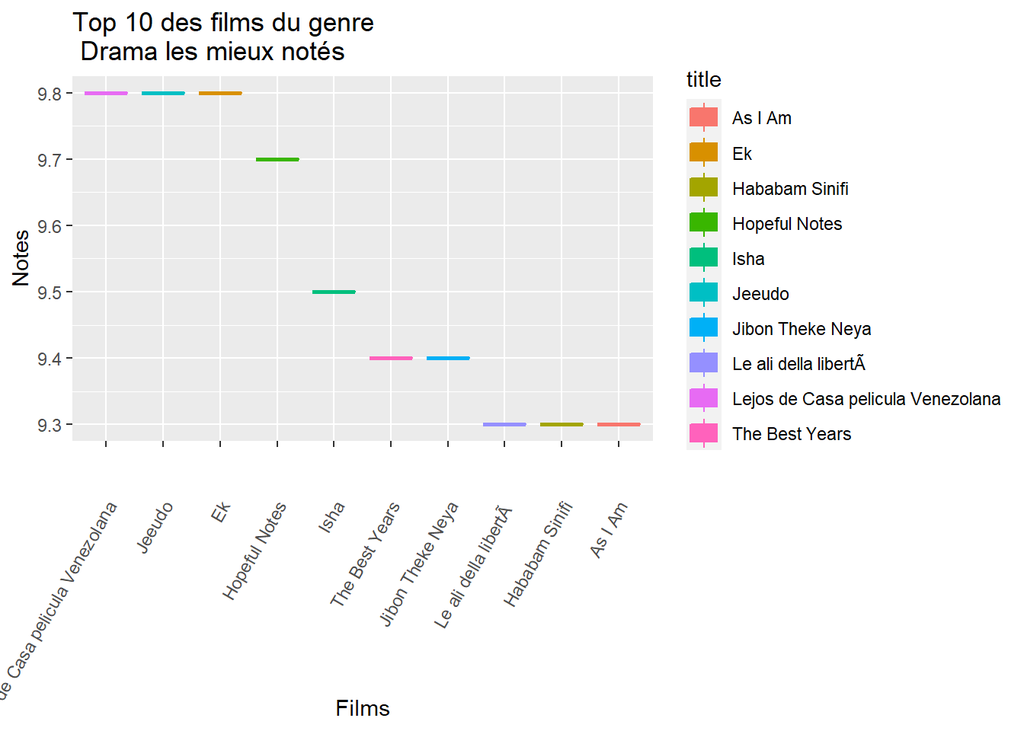

```r
Dra <- dt %>%
  filter(str_detect(genre, "Drama")) %>%
  select(avg_vote, title) %>%
  arrange(desc(avg_vote)) %>%
  head(10)
ggplot(Dra, aes(y = avg_vote, x =fct_rev(fct_reorder(title, avg_vote,.fun="median")),color = title)) +
  theme(axis.text.x = element_text(vjust=.8, hjust=1, angle=60)) +
  geom_boxplot(aes(fill = title)) +
  xlab("Films") +
  ylab("Notes") +
  ggtitle("Top 10 des films du genre\n Drama les mieux notés ")
```

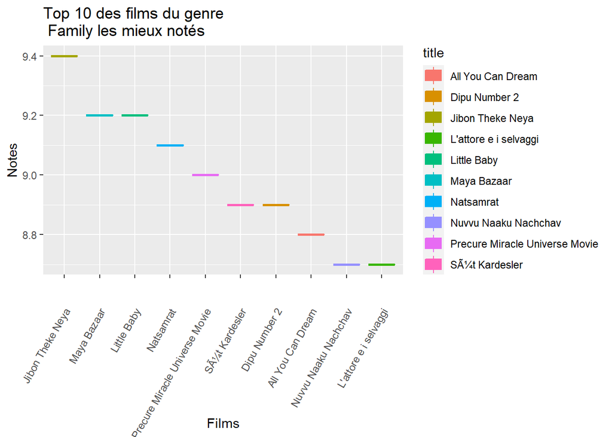

```r
Fam <- dt %>%
  filter(str_detect(genre, "Family")) %>%
  select(avg_vote, title) %>%
  arrange(desc(avg_vote)) %>%
  head(10)
ggplot(Fam, aes(y = avg_vote, x =fct_rev(fct_reorder(title, avg_vote,.fun="median")),color = title)) +
  theme(axis.text.x = element_text(vjust=.8, hjust=1, angle=60)) +
  geom_boxplot(aes(fill = title)) +
  xlab("Films") +
  ylab("Notes") +
  ggtitle("Top 10 des films du genre\n Family les mieux notés ")
```

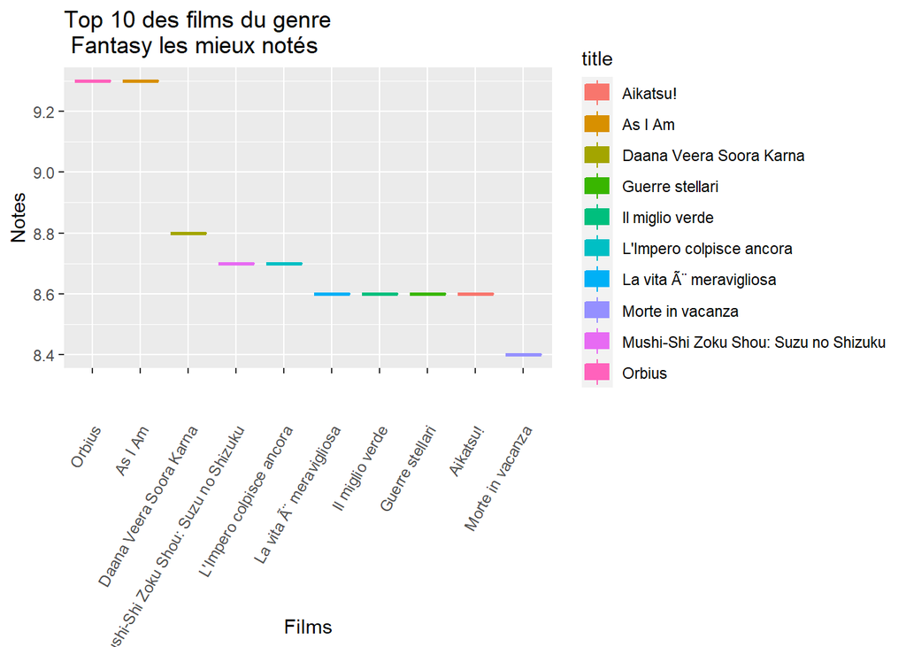

```r
Fan <- dt %>%
  filter(str_detect(genre, "Fantasy")) %>%
  select(avg_vote, title) %>%
  arrange(desc(avg_vote)) %>%
  head(10)
ggplot(Fan, aes(y = avg_vote, x =fct_rev(fct_reorder(title, avg_vote,.fun="median")),color = title)) +
  theme(axis.text.x = element_text(vjust=.8, hjust=1, angle=60)) +
  geom_boxplot(aes(fill = title)) +
  xlab("Films") +
  ylab("Notes") +
  ggtitle("Top 10 des films du genre\n Fantasy les mieux notés ")
```

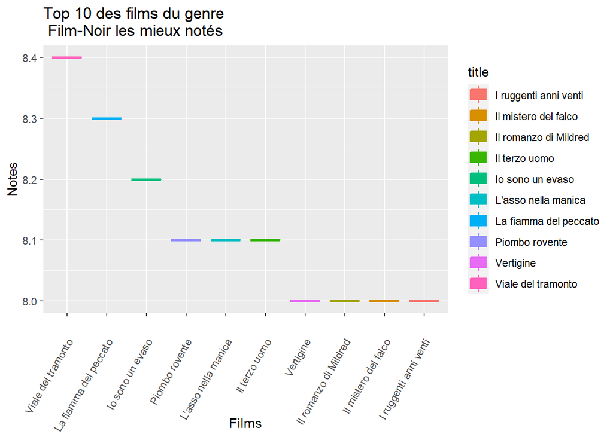

```r
Film <- dt %>%
  filter(str_detect(genre, "Film-Noir")) %>%
  select(avg_vote, title) %>%
  arrange(desc(avg_vote)) %>%
  head(10)
ggplot(Film, aes(y = avg_vote, x =fct_rev(fct_reorder(title, avg_vote,.fun="median")),color = title)) +
  theme(axis.text.x = element_text(vjust=.8, hjust=1, angle=60)) +
  geom_boxplot(aes(fill = title)) +
  xlab("Films") +
  ylab("Notes") +
  ggtitle("Top 10 des films du genre\n Film-Noir les mieux notés ")
```

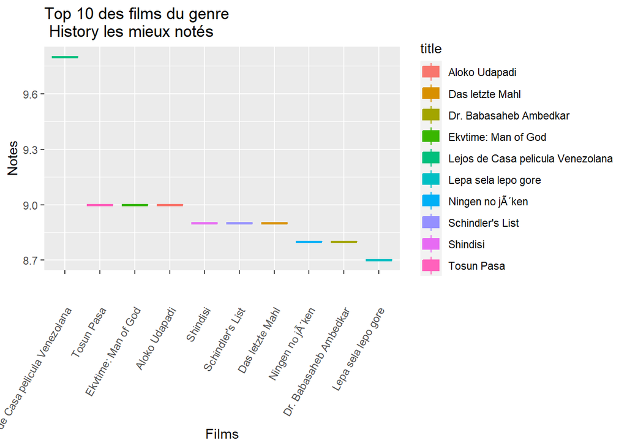

```r
His <- dt %>%
  filter(str_detect(genre, "History")) %>%
  select(avg_vote, title) %>%
  arrange(desc(avg_vote)) %>%
  head(10)
ggplot(His, aes(y = avg_vote, x =fct_rev(fct_reorder(title, avg_vote,.fun="median")),color = title)) +
  theme(axis.text.x = element_text(vjust=.8, hjust=1, angle=60)) +
  geom_boxplot(aes(fill = title)) +
  xlab("Films") +
  ylab("Notes") +
  ggtitle("Top 10 des films du genre\n History les mieux notés ")
```

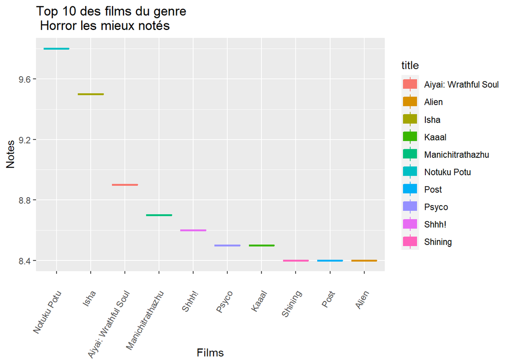

```r
Ho <- dt %>%
  filter(str_detect(genre, "Horror")) %>%
  select(avg_vote, title) %>%
  arrange(desc(avg_vote)) %>%
  head(10)
ggplot(Ho, aes(y = avg_vote, x =fct_rev(fct_reorder(title, avg_vote,.fun="median")),color = title)) +
  theme(axis.text.x = element_text(vjust=.8, hjust=1, angle=60)) +
  geom_boxplot(aes(fill = title)) +
  xlab("Films") +
  ylab("Notes") +
  ggtitle("Top 10 des films du genre\n Horror les mieux notés ")
```

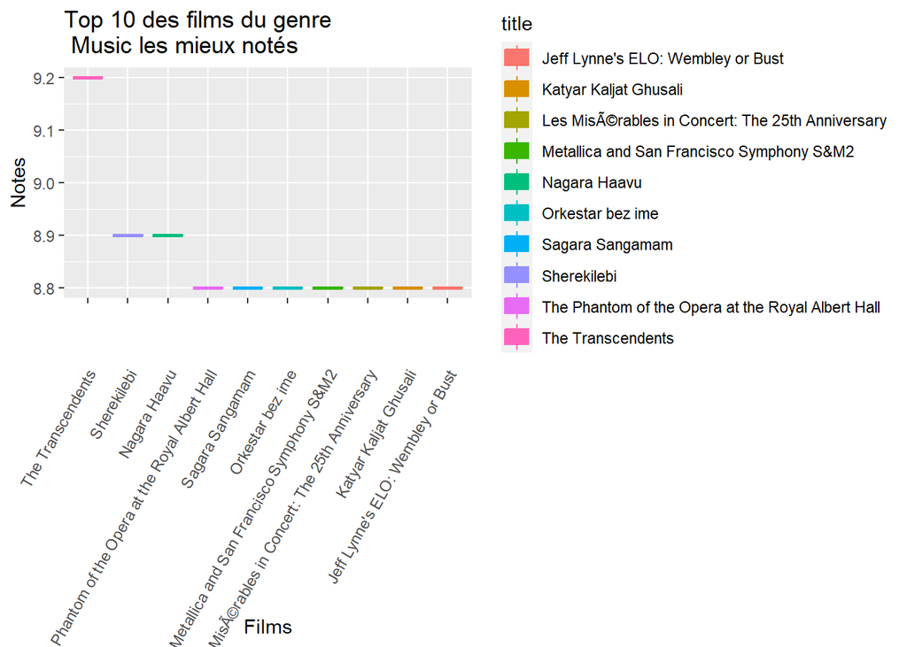

```r
Mus <- dt %>%
  filter(str_detect(genre, "Music")) %>%
  select(avg_vote, title) %>%
  arrange(desc(avg_vote)) %>%
  head(10)
ggplot(Mus, aes(y = avg_vote, x =fct_rev(fct_reorder(title, avg_vote,.fun="median")),color = title)) +
  theme(axis.text.x = element_text(vjust=.8, hjust=1, angle=60)) +
  geom_boxplot(aes(fill = title)) +
  xlab("Films") +
  ylab("Notes") +
  ggtitle("Top 10 des films du genre\n Music les mieux notés ")
```

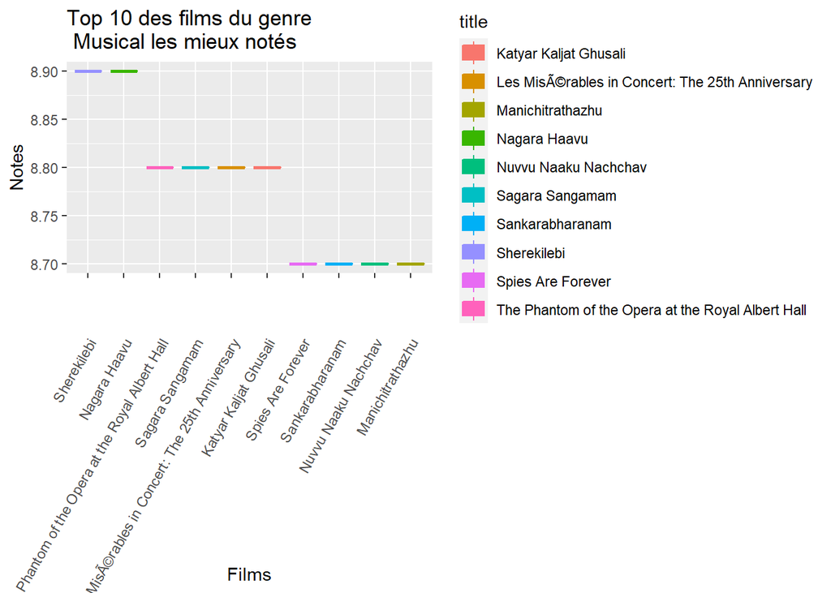

```r
Mu <- dt %>%
  filter(str_detect(genre, "Musical")) %>%
  select(avg_vote, title) %>%
  arrange(desc(avg_vote)) %>%
  head(10)
ggplot(Mu, aes(y = avg_vote, x =fct_rev(fct_reorder(title, avg_vote,.fun="median")),color = title)) +
  theme(axis.text.x = element_text(vjust=.8, hjust=1, angle=60)) +
  geom_boxplot(aes(fill = title)) +
  xlab("Films") +
  ylab("Notes") +
  ggtitle("Top 10 des films du genre\n Musical les mieux notés ")
```

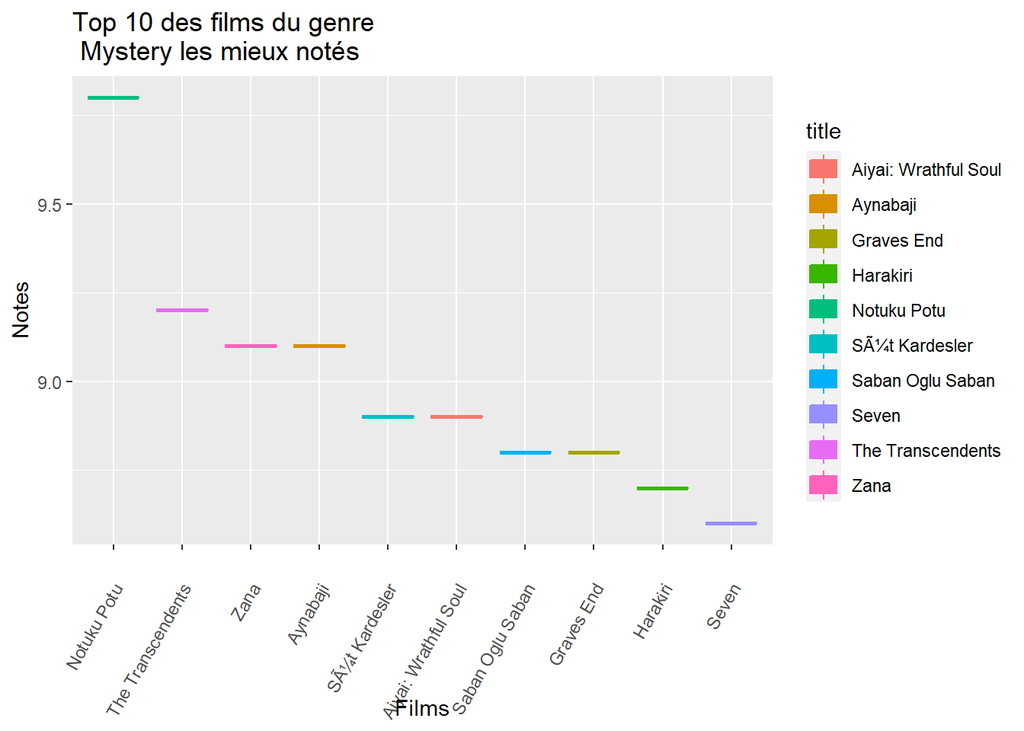

```r
Mys <- dt %>%
  filter(str_detect(genre, "Mystery")) %>%
  select(avg_vote, title) %>%
  arrange(desc(avg_vote)) %>%
  head(10)
ggplot(Mys, aes(y = avg_vote, x =fct_rev(fct_reorder(title, avg_vote,.fun="median")),color = title)) +
  theme(axis.text.x = element_text(vjust=.8, hjust=1, angle=60)) +
  geom_boxplot(aes(fill = title)) +
  xlab("Films") +
  ylab("Notes") +
  ggtitle("Top 10 des films du genre\n Mystery les mieux notés ")
```

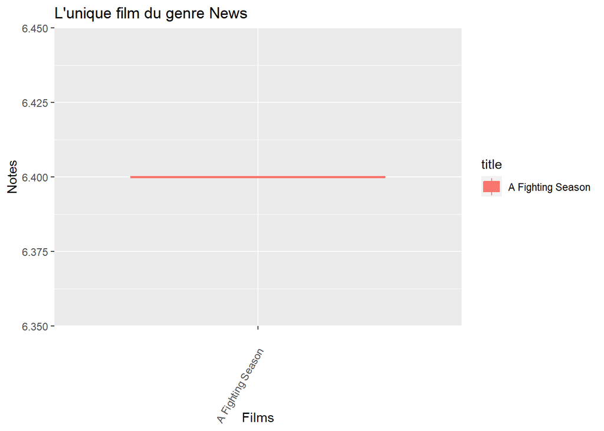

```r
News <- dt %>%
  filter(str_detect(genre, "News")) %>%
  select(avg_vote, title) %>%
  arrange(desc(avg_vote)) %>%
  head(10)
ggplot(News, aes(y = avg_vote, x =fct_rev(fct_reorder(title, avg_vote,.fun="median")),color = title)) +
  theme(axis.text.x = element_text(vjust=.8, hjust=1, angle=60)) +
  geom_boxplot(aes(fill = title)) +
  xlab("Films") +
  ylab("Notes") +
  ggtitle("L'unique film du genre News")
```

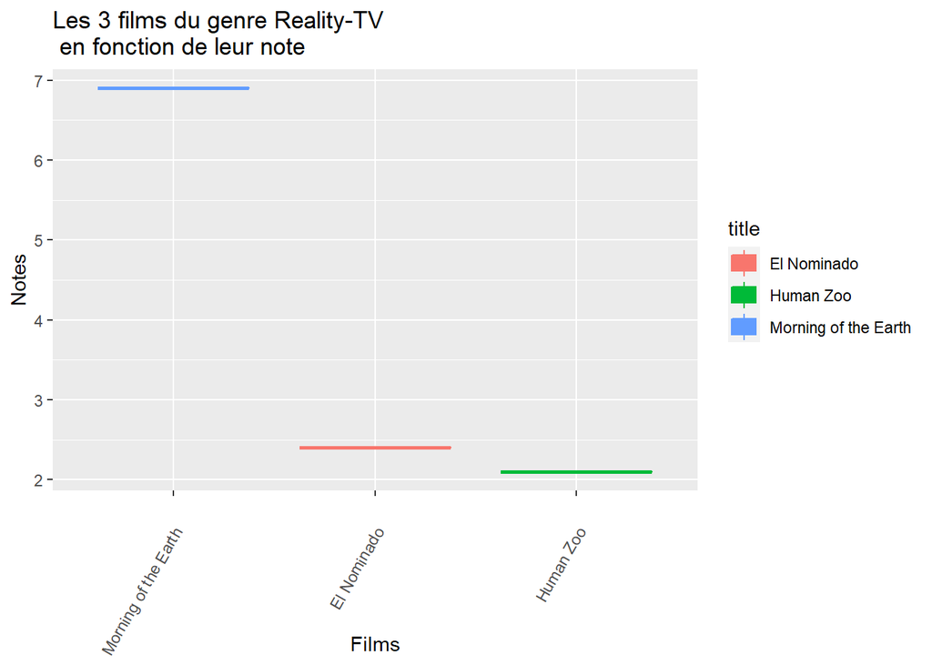

```r
Real <- dt %>%
  filter(str_detect(genre, "Reality-TV")) %>%
  select(avg_vote, title) %>%
  arrange(desc(avg_vote)) %>%
  head(10)
ggplot(Real, aes(y = avg_vote, x =fct_rev(fct_reorder(title, avg_vote,.fun="median")),color = title)) +
  theme(axis.text.x = element_text(vjust=.8, hjust=1, angle=60)) +
  geom_boxplot(aes(fill = title)) +
  xlab("Films") +
  ylab("Notes") +
  ggtitle("Les 3 films du genre Reality-TV\n en fonction de leur note")
```

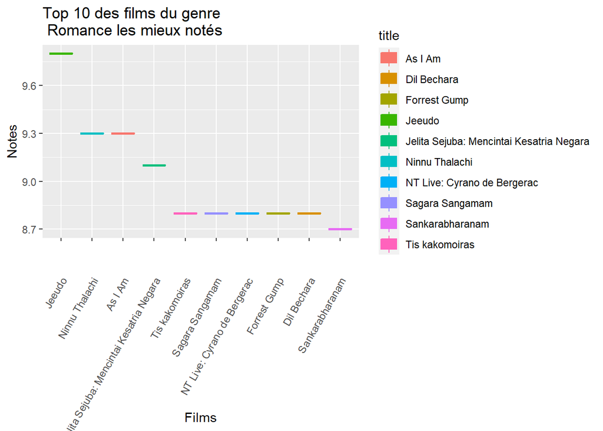

```r
Ro <- dt %>%
  filter(str_detect(genre, "Romance")) %>%
  select(avg_vote, title) %>%
  arrange(desc(avg_vote)) %>%
  head(10)
ggplot(Ro, aes(y = avg_vote, x =fct_rev(fct_reorder(title, avg_vote,.fun="median")),color = title)) +
  theme(axis.text.x = element_text(vjust=.8, hjust=1, angle=60)) +
  geom_boxplot(aes(fill = title)) +
  xlab("Films") +
  ylab("Notes") +
  ggtitle("Top 10 des films du genre\n Romance les mieux notés ")
```

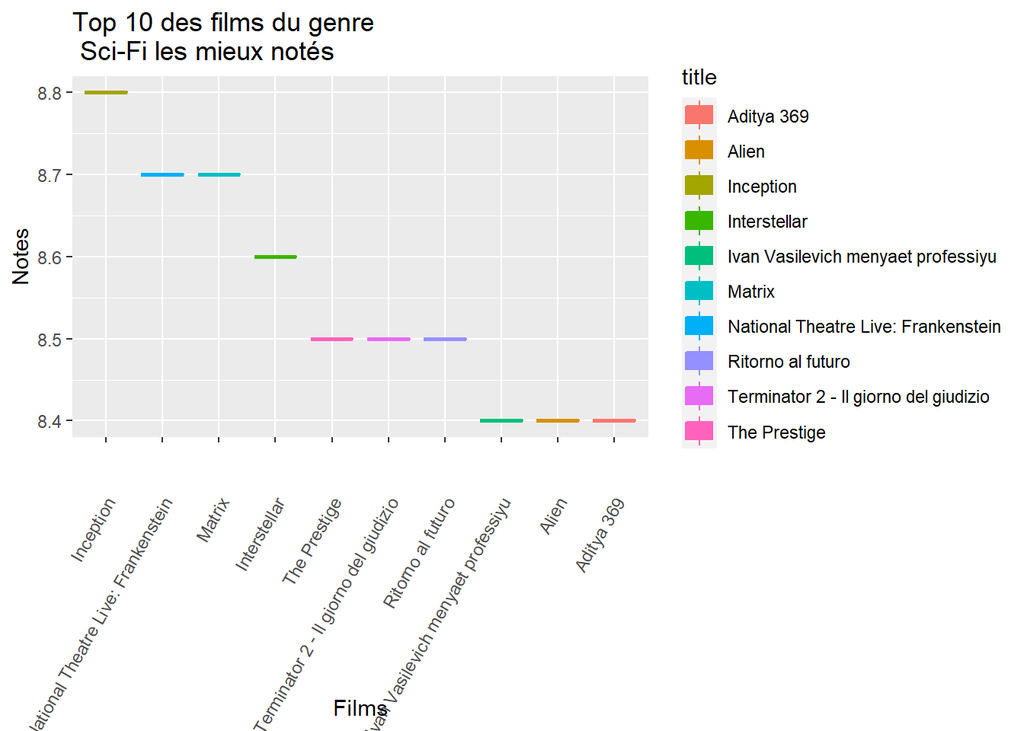

```r
Sci <- dt %>%
  filter(str_detect(genre, "Sci-Fi")) %>%
  select(avg_vote, title) %>%
  arrange(desc(avg_vote)) %>%
  head(10)
ggplot(Sci, aes(y = avg_vote, x =fct_rev(fct_reorder(title, avg_vote,.fun="median")),color = title)) +
  theme(axis.text.x = element_text(vjust=.8, hjust=1, angle=60)) +
  geom_boxplot(aes(fill = title)) +
  xlab("Films") +
  ylab("Notes") +
  ggtitle("Top 10 des films du genre\n Sci-Fi les mieux notés ")
```

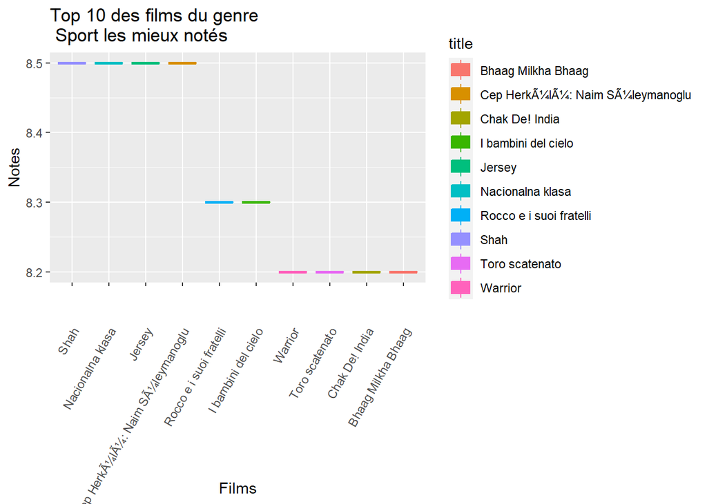

```r
Sp <- dt %>%
  filter(str_detect(genre, "Sport")) %>%
  select(avg_vote, title) %>%
  arrange(desc(avg_vote)) %>%
  head(10)
ggplot(Sp, aes(y = avg_vote, x =fct_rev(fct_reorder(title, avg_vote,.fun="median")),color = title)) +
  theme(axis.text.x = element_text(vjust=.8, hjust=1, angle=60)) +
  geom_boxplot(aes(fill = title)) +
  xlab("Films") +
  ylab("Notes") +
  ggtitle("Top 10 des films du genre\n Sport les mieux notés ")
```